# part_1

```python
import pandas as pd
import numpy as np
import matplotlib.pyplot as plt
import seaborn as sns
from pandas_profiling import ProfileReport
```

**Steps and tasks**

1. Import and warehouse data:  
• Import all the given datasets and explore shape and size of each

```python
df_normal = pd.read_csv("Part1 - Normal.csv")
df_type_H = pd.read_csv("Part1 - Type_H.csv")
df_type_S = pd.read_csv("Part1 - Type_S.csv")
```

```python
df_normal.head()
```

|  | P_incidence | P_tilt | L_angle | S_slope | P_radius | S_Degree | Class |
| --- | --- | --- | --- | --- | --- | --- | --- |
| 0 | 38.505273 | 16.964297 | 35.112814 | 21.540976 | 127.632875 | 7.986683 | Normal |
| 1 | 54.920858 | 18.968430 | 51.601455 | 35.952428 | 125.846646 | 2.001642 | Normal |
| 2 | 44.362490 | 8.945435 | 46.902096 | 35.417055 | 129.220682 | 4.994195 | Normal |
| 3 | 48.318931 | 17.452121 | 48.000000 | 30.866809 | 128.980308 | -0.910941 | Normal |
| 4 | 45.701789 | 10.659859 | 42.577846 | 35.041929 | 130.178314 | -3.388910 | Normal |

```python
df_type_H.head()
```

|  | P_incidence | P_tilt | L_angle | S_slope | P_radius | S_Degree | Class |
| --- | --- | --- | --- | --- | --- | --- | --- |
| 0 | 63.027818 | 22.552586 | 39.609117 | 40.475232 | 98.672917 | -0.254400 | Type_H |
| 1 | 39.056951 | 10.060991 | 25.015378 | 28.995960 | 114.405425 | 4.564259 | Type_H |
| 2 | 68.832021 | 22.218482 | 50.092194 | 46.613539 | 105.985135 | -3.530317 | Type_H |
| 3 | 69.297008 | 24.652878 | 44.311238 | 44.644130 | 101.868495 | 11.211523 | Type_H |
| 4 | 49.712859 | 9.652075 | 28.317406 | 40.060784 | 108.168725 | 7.918501 | Type_H |

```python
df_type_S.head()
```

|  | P_incidence | P_tilt | L_angle | S_slope | P_radius | S_Degree | Class |
| --- | --- | --- | --- | --- | --- | --- | --- |
| 0 | 74.377678 | 32.053104 | 78.772013 | 42.324573 | 143.560690 | 56.125906 | Type_S |
| 1 | 89.680567 | 32.704435 | 83.130732 | 56.976132 | 129.955476 | 92.027277 | Type_S |
| 2 | 44.529051 | 9.433234 | 52.000000 | 35.095817 | 134.711772 | 29.106575 | Type_S |
| 3 | 77.690577 | 21.380645 | 64.429442 | 56.309932 | 114.818751 | 26.931841 | Type_S |
| 4 | 76.147212 | 21.936186 | 82.961502 | 54.211027 | 123.932010 | 10.431972 | Type_S |

```python
df_normal.tail()
```

|  | P_incidence | P_tilt | L_angle | S_slope | P_radius | S_Degree | Class |
| --- | --- | --- | --- | --- | --- | --- | --- |
| 95 | 47.903565 | 13.616688 | 36.000000 | 34.286877 | 117.449062 | -4.245395 | Normal |
| 96 | 53.936748 | 20.721496 | 29.220534 | 33.215251 | 114.365845 | -0.421010 | Normal |
| 97 | 61.446597 | 22.694968 | 46.170347 | 38.751628 | 125.670725 | -2.707880 | Normal |
| 98 | 45.252792 | 8.693157 | 41.583126 | 36.559635 | 118.545842 | 0.214750 | Normal |
| 99 | 33.841641 | 5.073991 | 36.641233 | 28.767649 | 123.945244 | -0.199249 | Normal |

```python
df_type_H.tail()
```

|  | P_incidence | P_tilt | L_angle | S_slope | P_radius | S_Degree | Class |
| --- | --- | --- | --- | --- | --- | --- | --- |
| 55 | 47.657730 | 13.277385 | 36.679985 | 34.380345 | 98.249781 | 6.273012 | Type_H |
| 56 | 43.349606 | 7.467469 | 28.065483 | 35.882137 | 112.776187 | 5.753277 | Type_H |
| 57 | 46.855781 | 15.351514 | 38.000000 | 31.504267 | 116.250917 | 1.662706 | Type_H |
| 58 | 43.203185 | 19.663146 | 35.000000 | 23.540039 | 124.846109 | -2.919076 | Type_H |
| 59 | 48.109236 | 14.930725 | 35.564683 | 33.178512 | 124.056452 | 7.947905 | Type_H |

```python
df_type_S.tail()
```

|  | P_incidence | P_tilt | L_angle | S_slope | P_radius | S_Degree | Class |
| --- | --- | --- | --- | --- | --- | --- | --- |
| 145 | 80.111572 | 33.942432 | 85.101608 | 46.169139 | 125.593624 | 100.292107 | Type_S |
| 146 | 95.480229 | 46.550053 | 59.000000 | 48.930176 | 96.683903 | 77.283072 | Type_S |
| 147 | 74.094731 | 18.823727 | 76.032156 | 55.271004 | 128.405731 | 73.388216 | Type_S |
| 148 | 87.679087 | 20.365613 | 93.822416 | 67.313473 | 120.944829 | 76.730629 | Type_S |
| 149 | 48.259920 | 16.417462 | 36.329137 | 31.842457 | 94.882336 | 28.343799 | Type_S |

```python
# check shape and size
print(f"df_normal shape: {df_normal.shape}")
print(f"df_type_H shape: {df_type_H.shape}")
print(f"df_type_S shape: {df_type_S.shape}")
```

```
df_normal shape: (100, 7)
df_type_H shape: (60, 7)
df_type_S shape: (150, 7)
```

```python
# compare columns across dataframes
print(f"df_normal columns: {list(df_normal.columns)}")
print(f"df_type_H columns: {list(df_type_H.columns)}")
print(f"df_type_S columns: {list(df_type_S.columns)}")
```

```
df_normal columns: ['P_incidence', 'P_tilt', 'L_angle', 'S_slope', 'P_radius', 'S_Degree', 'Class']
df_type_H columns: ['P_incidence', 'P_tilt', 'L_angle', 'S_slope', 'P_radius', 'S_Degree', 'Class']
df_type_S columns: ['P_incidence', 'P_tilt', 'L_angle', 'S_slope', 'P_radius', 'S_Degree', 'Class']
```

```python
df_normal.info()
```

```
<class 'pandas.core.frame.DataFrame'>
RangeIndex: 100 entries, 0 to 99
Data columns (total 7 columns):
 #   Column       Non-Null Count  Dtype
---  ------       --------------  -----
 0   P_incidence  100 non-null    float64
 1   P_tilt       100 non-null    float64
 2   L_angle      100 non-null    float64
 3   S_slope      100 non-null    float64
 4   P_radius     100 non-null    float64
 5   S_Degree     100 non-null    float64
 6   Class        100 non-null    object
dtypes: float64(6), object(1)
memory usage: 5.6+ KB
```

```python
df_type_H.info()
```

```
<class 'pandas.core.frame.DataFrame'>
RangeIndex: 60 entries, 0 to 59
Data columns (total 7 columns):
 #   Column       Non-Null Count  Dtype
---  ------       --------------  -----
 0   P_incidence  60 non-null     float64
 1   P_tilt       60 non-null     float64
 2   L_angle      60 non-null     float64
 3   S_slope      60 non-null     float64
 4   P_radius     60 non-null     float64
 5   S_Degree     60 non-null     float64
 6   Class        60 non-null     object
dtypes: float64(6), object(1)
memory usage: 3.4+ KB
```

```python
df_type_S.info()
```

```
<class 'pandas.core.frame.DataFrame'>
RangeIndex: 150 entries, 0 to 149
Data columns (total 7 columns):
 #   Column       Non-Null Count  Dtype
---  ------       --------------  -----
 0   P_incidence  150 non-null    float64
 1   P_tilt       150 non-null    float64
 2   L_angle      150 non-null    float64
 3   S_slope      150 non-null    float64
 4   P_radius     150 non-null    float64
 5   S_Degree     150 non-null    float64
 6   Class        150 non-null    object
dtypes: float64(6), object(1)
memory usage: 8.3+ KB
```

### All dataframes have the same datatypes and columns

• Merge all datasets onto one and explore final shape and size

```python
df = pd.concat([df_normal, df_type_H, df_type_S], ignore_index=True, sort=False)
df.shape
```

```
(310, 7)
```

2. Data cleansing:  
• Explore and if required correct the datatypes of each attribute  
• Explore for null values in the attributes and if required drop or impute values

```python
# standardize target class
df["Class"].value_counts()
```

```
Type_S    133
Normal     73
Type_H     37
Nrmal      27
type_h     23
tp_s       17
Name: Class, dtype: int64
```

```python
df["Class"].replace({"Nrmal": "Normal", "type_h": "Type_H", "tp_s": "Type_S"}, inplace=True)
df["Class"].value_counts()
```

```
Type_S    150
Normal    100
Type_H     60
Name: Class, dtype: int64
```

```python
df.info()
```

```
<class 'pandas.core.frame.DataFrame'>
RangeIndex: 310 entries, 0 to 309
Data columns (total 7 columns):
 #   Column       Non-Null Count  Dtype
---  ------       --------------  -----
 0   P_incidence  310 non-null    float64
 1   P_tilt       310 non-null    float64
 2   L_angle      310 non-null    float64
 3   S_slope      310 non-null    float64
 4   P_radius     310 non-null    float64
 5   S_Degree     310 non-null    float64
 6   Class        310 non-null    object
dtypes: float64(6), object(1)
memory usage: 17.1+ KB
```

```python
# convert object to category
df["Class"] = df["Class"].astype('category')
df.info()
```

```
<class 'pandas.core.frame.DataFrame'>
RangeIndex: 310 entries, 0 to 309
Data columns (total 7 columns):
 #   Column       Non-Null Count  Dtype
---  ------       --------------  -----
 0   P_incidence  310 non-null    float64
 1   P_tilt       310 non-null    float64
 2   L_angle      310 non-null    float64
 3   S_slope      310 non-null    float64
 4   P_radius     310 non-null    float64
 5   S_Degree     310 non-null    float64
 6   Class        310 non-null    category
dtypes: category(1), float64(6)
memory usage: 15.1 KB
```

```python
# check for null values
df.isnull().sum()
```

```
P_incidence    0
P_tilt         0
L_angle        0
S_slope        0
P_radius       0
S_Degree       0
Class          0
dtype: int64
```

```python
df.describe().T
```

|  | count | mean | std | min | 25% | 50% | 75% | max |
| --- | --- | --- | --- | --- | --- | --- | --- | --- |
| P_incidence | 310.0 | 60.496653 | 17.236520 | 26.147921 | 46.430294 | 58.691038 | 72.877696 | 129.834041 |
| P_tilt | 310.0 | 17.542822 | 10.008330 | -6.554948 | 10.667069 | 16.357689 | 22.120395 | 49.431864 |
| L_angle | 310.0 | 51.930930 | 18.554064 | 14.000000 | 37.000000 | 49.562398 | 63.000000 | 125.742385 |
| S_slope | 310.0 | 42.953831 | 13.423102 | 13.366931 | 33.347122 | 42.404912 | 52.695888 | 121.429566 |
| P_radius | 310.0 | 117.920655 | 13.317377 | 70.082575 | 110.709196 | 118.268178 | 125.467674 | 163.071041 |
| S_Degree | 310.0 | 26.296694 | 37.559027 | -11.058179 | 1.603727 | 11.767934 | 41.287352 | 418.543082 |

```python
# profile = ProfileReport(df, title='Pandas Profiling Report', explorative=True)
# profile.to_file("part1_eda.html")
```

### There are no null values we converted the target class datatype from object to category

3. Data analysis & visualisation:  
• Perform detailed statistical analysis on the data.  
• Perform a detailed univariate, bivariate and multivariate analysis with appropriate detailed comments after each analysis.

```python
def univariateAnalysis_numeric(column,nbins):
    print("Description of " + column)
    print("----------------------------------------------------------------------------")
    print(df[column].describe(),end=' ')


    plt.figure()
    print("Distribution of " + column)
    print("----------------------------------------------------------------------------")
    sns.displot(df[column], kind='hist', color='g');
    plt.show()

    plt.figure()
    print("BoxPlot of " + column)
    print("----------------------------------------------------------------------------")
    ax = sns.boxplot(x=df[column])
    plt.show()
```

```
Description of P_incidence
----------------------------------------------------------------------------
count    310.000000
mean      60.496653
std       17.236520
min       26.147921
25%       46.430294
50%       58.691038
75%       72.877696
max      129.834041
Name: P_incidence, dtype: float64 Distribution of P_incidence
----------------------------------------------------------------------------
```

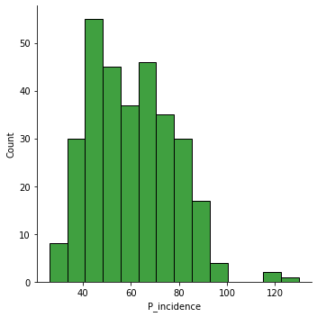

```
BoxPlot of P_incidence
----------------------------------------------------------------------------
```

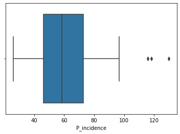

```python
univariateAnalysis_numeric("P_incidence",20)
```

```python
# there are few outliers in the data and we dont want to drop them and lose useful information,hence, we will replace it with closest value within our acceptable range using the below function
```

```python
def treat_outlier(x):
    # taking 5,25,75 percentile of column
    q5= np.percentile(x,5)
    q25=np.percentile(x,25)
    q75=np.percentile(x,75)
    dt=np.percentile(x,95)
    #calculationg IQR range
    IQR=q75-q25
    #Calculating minimum threshold
    lower_bound=q25-(1.5*IQR)
    upper_bound=q75+(1.5*IQR)
    #Capping outliers
    return x.apply(lambda y: dt if y > upper_bound else y).apply(lambda y: q5 if y < lower_bound else y)
```

```python
df["P_incidence"] = treat_outlier(df["P_incidence"])
```

```
Description of P_incidence
----------------------------------------------------------------------------
count    310.000000
mean      60.173121
std       16.371041
min       26.147921
25%       46.430294
50%       58.691038
75%       72.877696
max       96.657315
Name: P_incidence, dtype: float64 Distribution of P_incidence
----------------------------------------------------------------------------
```

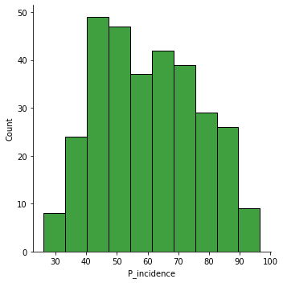

```
BoxPlot of P_incidence
----------------------------------------------------------------------------
```

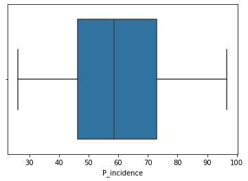

```python
univariateAnalysis_numeric("P_incidence",20)
```

```
Description of P_tilt
----------------------------------------------------------------------------
count    310.000000
mean      17.542822
std       10.008330
min       -6.554948
25%       10.667069
50%       16.357689
75%       22.120395
max       49.431864
Name: P_tilt, dtype: float64 Distribution of P_tilt
----------------------------------------------------------------------------
```

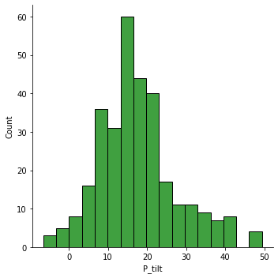

```
BoxPlot of P_tilt
----------------------------------------------------------------------------
```

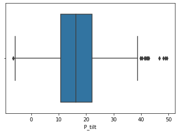

```python
univariateAnalysis_numeric("P_tilt",20)
```

```python
# there are few outliers in the data and we dont want to drop them and lose useful information,hence, we will replace it with closest value within our acceptable range
```

```
Description of P_tilt
----------------------------------------------------------------------------
count    310.000000
mean      17.342011
std        9.363440
min       -5.845994
25%       10.667069
50%       16.357689
75%       22.120395
max       38.750670
Name: P_tilt, dtype: float64 Distribution of P_tilt
----------------------------------------------------------------------------
```

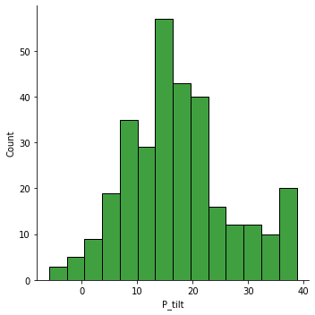

```
BoxPlot of P_tilt
----------------------------------------------------------------------------
```

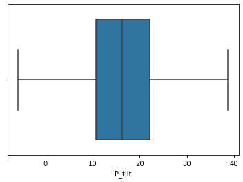

```python
df["P_tilt"] = treat_outlier(df["P_tilt"])
univariateAnalysis_numeric("P_tilt",20)
```

```
Description of L_angle
----------------------------------------------------------------------------
count    310.000000
mean      51.930930
std       18.554064
min       14.000000
25%       37.000000
50%       49.562398
75%       63.000000
max      125.742385
Name: L_angle, dtype: float64 Distribution of L_angle
----------------------------------------------------------------------------
```

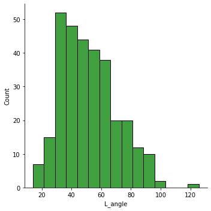

```
BoxPlot of L_angle
----------------------------------------------------------------------------
```

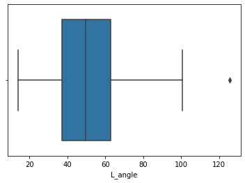

```python
univariateAnalysis_numeric("L_angle",20)
```

```python
# there are few outliers in the data and we dont want to drop them and lose useful information,hence, we will replace it with closest value within our acceptable range
```

```
Description of L_angle
----------------------------------------------------------------------------
count    310.000000
mean      51.801424
std       18.173404
min       14.000000
25%       37.000000
50%       49.562398
75%       63.000000
max      100.744220
Name: L_angle, dtype: float64 Distribution of L_angle
----------------------------------------------------------------------------
```

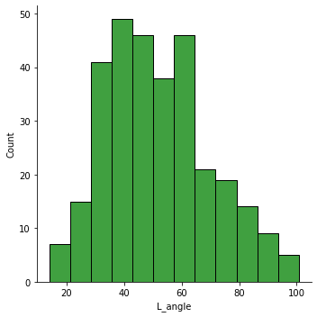

```
BoxPlot of L_angle
----------------------------------------------------------------------------
```

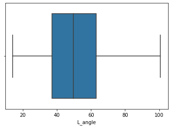

```python
df["L_angle"] = treat_outlier(df["L_angle"])
univariateAnalysis_numeric("L_angle",20)
```

```
Description of S_slope
----------------------------------------------------------------------------
count    310.000000
mean      42.953831
std       13.423102
min       13.366931
25%       33.347122
50%       42.404912
75%       52.695888
max      121.429566
Name: S_slope, dtype: float64 Distribution of S_slope
----------------------------------------------------------------------------
```

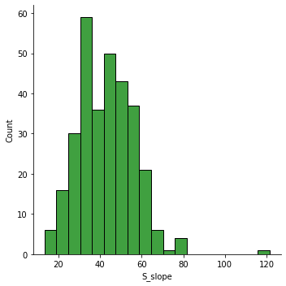

```
BoxPlot of S_slope
----------------------------------------------------------------------------
```

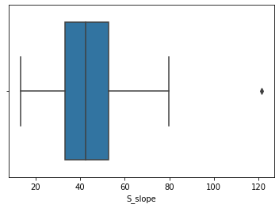

```python
univariateAnalysis_numeric("S_slope",20)
```

```python
# there are few outliers in the data and we dont want to drop them and lose useful information,hence, we will replace it with closest value within our acceptable range
```

```
Description of S_slope
----------------------------------------------------------------------------
count    310.000000
mean      42.766752
std       12.711092
min       13.366931
25%       33.347122
50%       42.404912
75%       52.695888
max       79.695154
Name: S_slope, dtype: float64 Distribution of S_slope
----------------------------------------------------------------------------
```

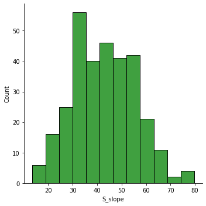

```
BoxPlot of S_slope
----------------------------------------------------------------------------
```

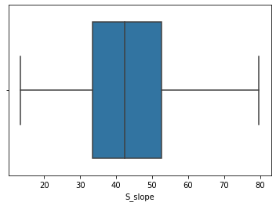

```python
df["S_slope"] = treat_outlier(df["S_slope"])
univariateAnalysis_numeric("S_slope",20)
```

```
Description of P_radius
----------------------------------------------------------------------------
count    310.000000
mean     117.920655
std       13.317377
min       70.082575
25%      110.709196
50%      118.268178
75%      125.467674
max      163.071041
Name: P_radius, dtype: float64 Distribution of P_radius
----------------------------------------------------------------------------
```

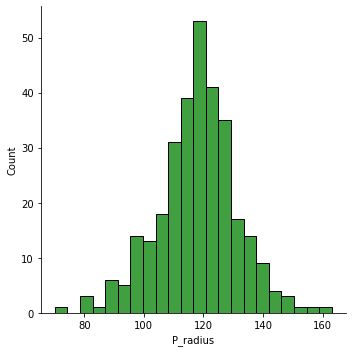

```
BoxPlot of P_radius
----------------------------------------------------------------------------
```

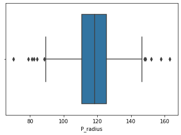

```python
univariateAnalysis_numeric("P_radius",20)
```

```python
# there are few outliers in the data and we dont want to drop them and lose useful information,hence, we will replace it with closest value within our acceptable range
```

```
Description of P_radius
----------------------------------------------------------------------------
count    310.000000
mean     117.963537
std       12.076746
min       89.307547
25%      110.709196
50%      118.268178
75%      125.467674
max      146.466001
Name: P_radius, dtype: float64 Distribution of P_radius
----------------------------------------------------------------------------
```

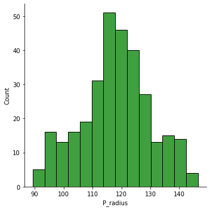

```
BoxPlot of P_radius
----------------------------------------------------------------------------
```

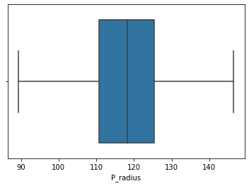

```python
df["P_radius"] = treat_outlier(df["P_radius"])
univariateAnalysis_numeric("P_radius",20)
```

```python
df.head()
```

|  | P_incidence | P_tilt | L_angle | S_slope | P_radius | S_Degree | Class |
| --- | --- | --- | --- | --- | --- | --- | --- |
| 0 | 38.505273 | 16.964297 | 35.112814 | 21.540976 | 127.632875 | 7.986683 | Normal |
| 1 | 54.920858 | 18.968430 | 51.601455 | 35.952428 | 125.846646 | 2.001642 | Normal |
| 2 | 44.362490 | 8.945435 | 46.902096 | 35.417055 | 129.220682 | 4.994195 | Normal |
| 3 | 48.318931 | 17.452121 | 48.000000 | 30.866809 | 128.980308 | -0.910941 | Normal |
| 4 | 45.701789 | 10.659859 | 42.577846 | 35.041929 | 130.178314 | -3.388910 | Normal |

```
Description of S_Degree
----------------------------------------------------------------------------
count    310.000000
mean      26.296694
std       37.559027
min      -11.058179
25%        1.603727
50%       11.767934
75%       41.287352
max      418.543082
Name: S_Degree, dtype: float64 Distribution of S_Degree
----------------------------------------------------------------------------
```

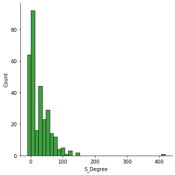

```
BoxPlot of S_Degree
----------------------------------------------------------------------------
```

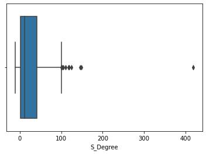

```python
univariateAnalysis_numeric("S_Degree",20)
```

```python
# there are few outliers in the data and we dont want to drop them and lose useful information,hence, we will replace it with closest value within our acceptable range
```

```
Description of S_Degree
----------------------------------------------------------------------------
count    310.000000
mean      24.119032
std       27.339360
min      -11.058179
25%        1.603727
50%       11.767934
75%       41.287352
max      100.292107
Name: S_Degree, dtype: float64 Distribution of S_Degree
----------------------------------------------------------------------------
```

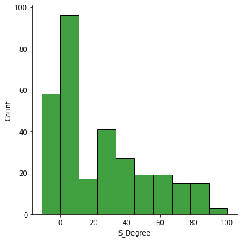

```
BoxPlot of S_Degree
----------------------------------------------------------------------------
```

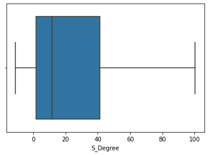

```python
df["S_Degree"] = treat_outlier(df["S_Degree"])
univariateAnalysis_numeric("S_Degree",20)
```